# STATS 513 Final Project

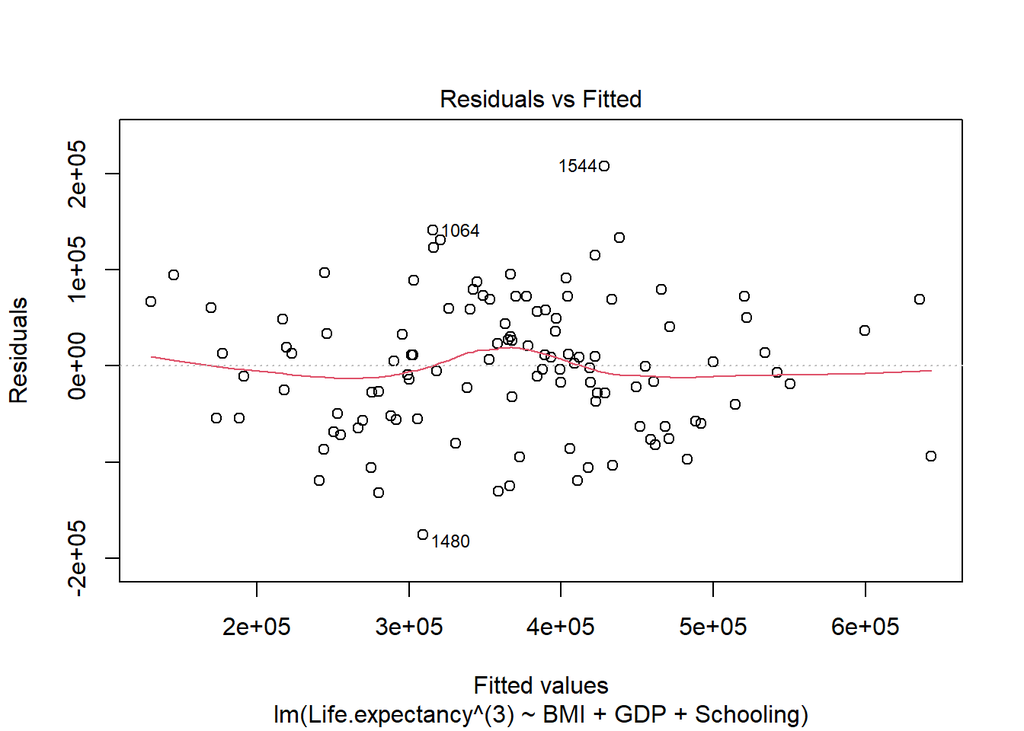

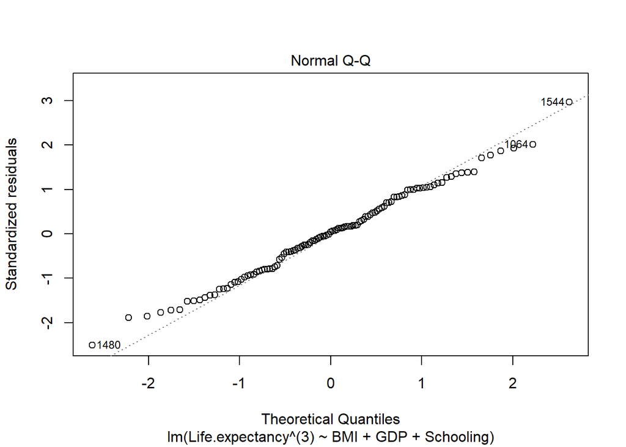

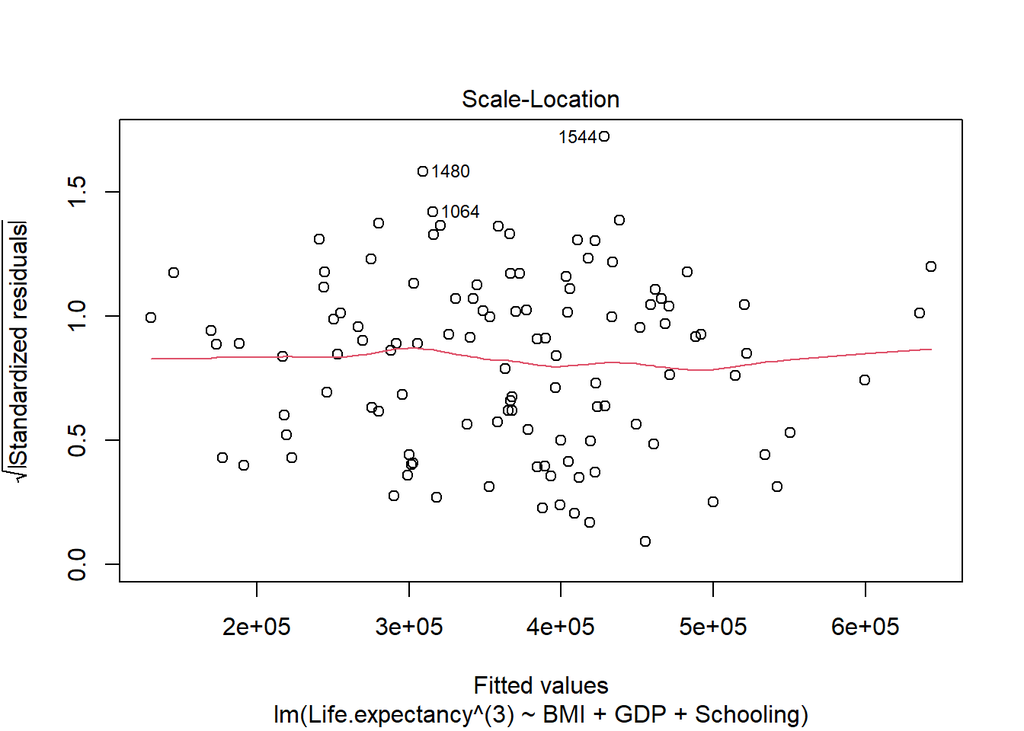

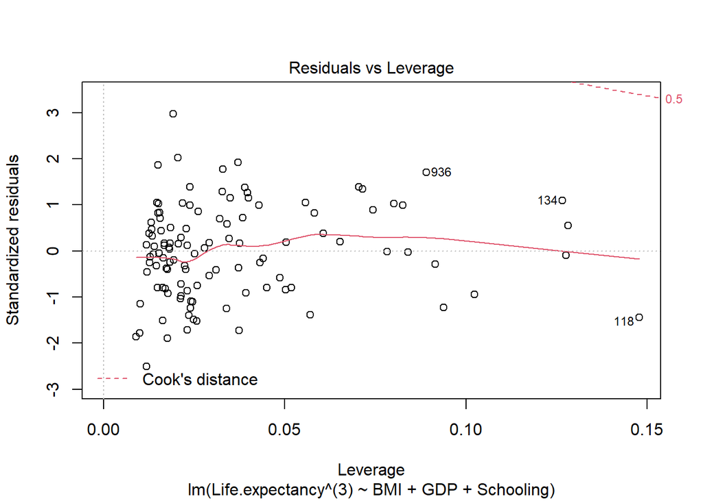

```r
plot(model_2)
```

```r
summary(lm(sqrt(abs(model_2$residuals))~model_2$fitted.value))
```

```
##
## Call:
## lm(formula = sqrt(abs(model_2$residuals)) ~ model_2$fitted.value)
##
## Residuals:
##     Min      1Q  Median      3Q     Max
## -188.81  -72.54   13.48   65.18  241.51
##
## Coefficients:
##                        Estimate Std. Error t value Pr(>|t|)
## (Intercept)           2.332e+02  3.290e+01   7.089 1.32e-10 ***
## model_2$fitted.value -4.467e-05  8.661e-05  -0.516    0.607
## ---
## Signif. codes:  0 '***' 0.001 '**' 0.01 '*' 0.05 '.' 0.1 ' ' 1
##
## Residual standard error: 93.32 on 111 degrees of freedom
## Multiple R-squared:  0.002391,   Adjusted R-squared:  -0.006596
## F-statistic: 0.2661 on 1 and 111 DF,  p-value: 0.607
```

```r
model_3=lm(Life.expectancy^(3) ~ .-infant.deaths-Polio-under.five.deaths, data=train_data)
summary(model_3)
```

```
##
## Call:
## lm(formula = Life.expectancy^(3) ~ . - infant.deaths - Polio -
##     under.five.deaths, data = train_data)
##
## Residuals:
##     Min      1Q  Median      3Q     Max
## -181831  -49255      75   42385  186832
##
## Coefficients:
##                    Estimate Std. Error t value Pr(>|t|)
## (Intercept)       45298.080  45672.959   0.992   0.3236
## StatusDeveloping -52348.072  25119.236  -2.084   0.0396 *
## Alcohol           -3584.279   2369.292  -1.513   0.1333
## Hepatitis.B        -443.149    379.301  -1.168   0.2453
## BMI                 756.165    374.212   2.021   0.0459 *
## Diphtheria          813.427    490.212   1.659   0.1000
## GDP                   1.126      0.750   1.502   0.1362
## Schooling         25120.385   3775.053   6.654 1.33e-09 ***
## ---
## Signif. codes:  0 '***' 0.001 '**' 0.01 '*' 0.05 '.' 0.1 ' ' 1
##
## Residual standard error: 69600 on 105 degrees of freedom
## Multiple R-squared:  0.7013, Adjusted R-squared:  0.6814
## F-statistic: 35.22 on 7 and 105 DF,  p-value: < 2.2e-16
```

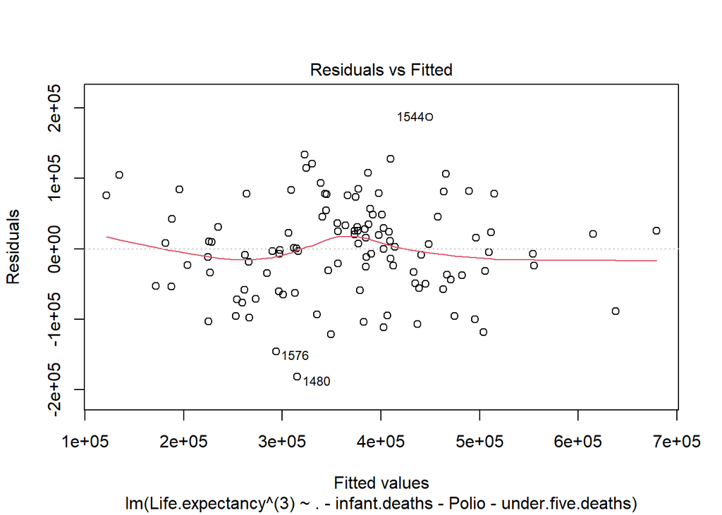

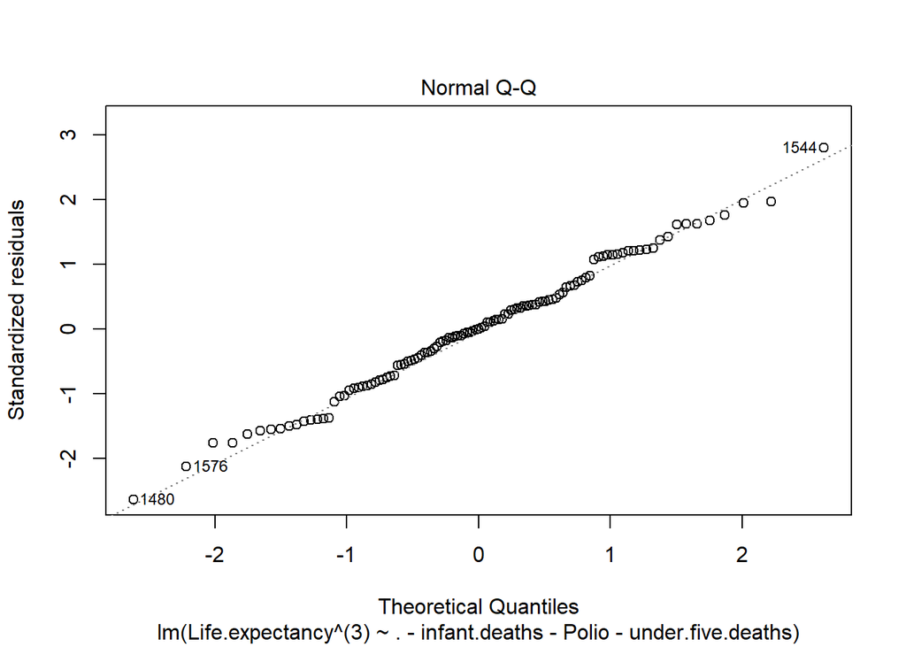

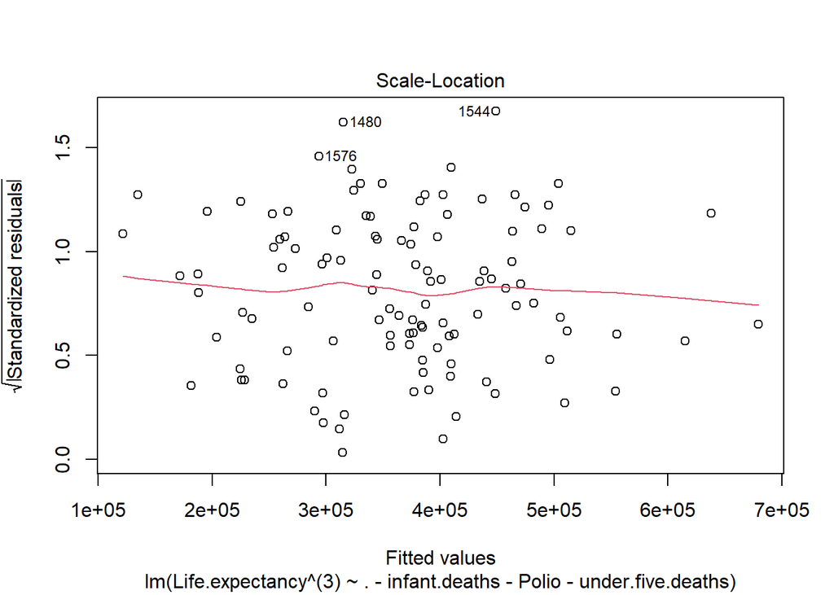

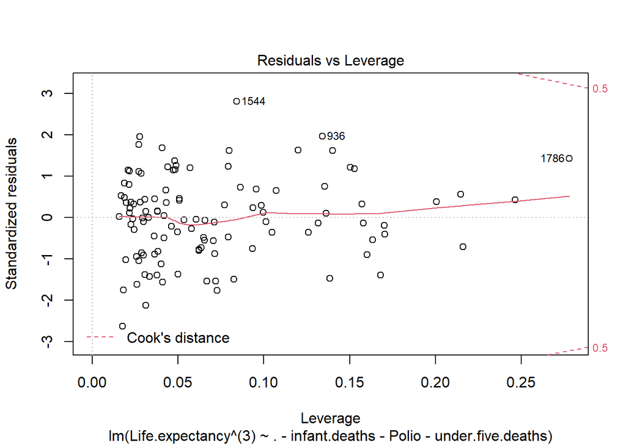

```r
plot(model_3)
```

```r
summary(lm(sqrt(abs(model_3$residuals))~model_3$fitted.value))
```

```
##
## Call:
## lm(formula = sqrt(abs(model_3$residuals)) ~ model_3$fitted.value)
##
## Residuals:
##      Min       1Q   Median       3Q      Max
## -203.883  -63.515    2.017   73.863  223.883
##
## Coefficients:
##                        Estimate Std. Error t value Pr(>|t|)
## (Intercept)           2.223e+02  3.287e+01   6.763 6.62e-10 ***
## model_3$fitted.value -3.105e-05  8.645e-05  -0.359     0.72
## ---
## Signif. codes:  0 '***' 0.001 '**' 0.01 '*' 0.05 '.' 0.1 ' ' 1
##
## Residual standard error: 94.48 on 111 degrees of freedom
## Multiple R-squared:  0.001161,   Adjusted R-squared:  -0.007838
## F-statistic: 0.129 on 1 and 111 DF,  p-value: 0.7202
```

Here we can see the model_1 we select with 5 predictors has a qq plot indicating the residuals may follow a short tail distribution, which is not a concern we need to worry about because it indicates the residuals have more concentrated distribution than normal distribution. Also, the heteroscadesticity is greatly reduced.However, we will try to use robust methods and see if they make any difference.

```r
gls <- lm(Life.expectancy ~ ., data=train_data)
summary(gls)
```

```
##
## Call:
## lm(formula = Life.expectancy ~ ., data = train_data)
##
## Residuals:
##      Min       1Q   Median       3Q      Max
## -16.4234  -2.8418   0.0844   2.9835  10.1985
##
## Coefficients:
##                     Estimate Std. Error t value Pr(>|t|)
## (Intercept)        5.096e+01  3.951e+00  12.898  < 2e-16 ***
## StatusDeveloping  -3.096e+00  1.782e+00  -1.738  0.08531 .
## infant.deaths      2.842e-01  1.040e-01   2.731  0.00743 **
## Alcohol           -2.405e-01  1.688e-01  -1.425  0.15730
## Hepatitis.B       -2.432e-02  2.696e-02  -0.902  0.36913
## BMI                5.509e-02  2.723e-02   2.023  0.04569 *
## under.five.deaths -2.235e-01  8.099e-02  -2.759  0.00686 **
## Polio             -8.464e-03  3.092e-02  -0.274  0.78485
## Diphtheria         4.731e-02  4.171e-02   1.134  0.25931
## GDP                5.245e-05  5.330e-05   0.984  0.32740
## Schooling          1.601e+00  2.883e-01   5.555 2.22e-07 ***
## ---
## Signif. codes:  0 '***' 0.001 '**' 0.01 '*' 0.05 '.' 0.1 ' ' 1
##
## Residual standard error: 4.918 on 102 degrees of freedom
## Multiple R-squared:  0.7029, Adjusted R-squared:  0.6737
## F-statistic: 24.13 on 10 and 102 DF,  p-value: < 2.2e-16
```

```r
gls_2 <- lm(Life.expectancy ~ .-under.five.deaths, data=train_data)
summary(gls_2)
```

```
##
## Call:
## lm(formula = Life.expectancy ~ . - under.five.deaths, data = train_data)
##
## Residuals:
##      Min       1Q   Median       3Q      Max
## -16.1386  -3.1688   0.5257   3.0712  10.6654
##
## Coefficients:
##                    Estimate Std. Error t value Pr(>|t|)
## (Intercept)       4.549e+01  3.525e+00  12.905  < 2e-16 ***
## StatusDeveloping -2.715e+00  1.833e+00  -1.481   0.1416
## infant.deaths    -7.059e-06  1.527e-02   0.000   0.9996
## Alcohol          -2.916e-01  1.731e-01  -1.685   0.0950 .
## Hepatitis.B      -1.646e-02  2.766e-02  -0.595   0.5531
## BMI               6.202e-02  2.797e-02   2.217   0.0288 *
## Polio            -8.060e-03  3.190e-02  -0.253   0.8010
## Diphtheria        5.459e-02  4.294e-02   1.271   0.2065
## GDP               3.716e-05  5.469e-05   0.680   0.4983
## Schooling         1.887e+00  2.776e-01   6.797 7.11e-10 ***
## ---
## Signif. codes:  0 '***' 0.001 '**' 0.01 '*' 0.05 '.' 0.1 ' ' 1
##
## Residual standard error: 5.073 on 103 degrees of freedom
## Multiple R-squared:  0.6807, Adjusted R-squared:  0.6528
## F-statistic:  24.4 on 9 and 103 DF,  p-value: < 2.2e-16
```

```r
## Least absolute deviations
library(quantreg)
glad <- rq(Life.expectancy ~ .-under.five.deaths, data=train_data)

summary(glad)
```

```
##
## Call: rq(formula = Life.expectancy ~ . - under.five.deaths, data = train_data)
##
## tau: [1] 0.5
##
## Coefficients:
##                  coefficients lower bd upper bd
## (Intercept)      44.07388     35.84412 51.49627
## StatusDeveloping -1.96141     -4.09853  0.79299
## infant.deaths    -0.00039     -0.05338  0.02002
## Alcohol          -0.38636     -0.50302 -0.07871
## Hepatitis.B      -0.00763     -0.05306  0.02140
## BMI               0.04777     -0.00661  0.09668
## Polio            -0.00877     -0.04568  0.02666
## Diphtheria        0.07129      0.03082  0.15507
## GDP               0.00003     -0.00007  0.00013
## Schooling         1.90609      1.40400  2.24507
```

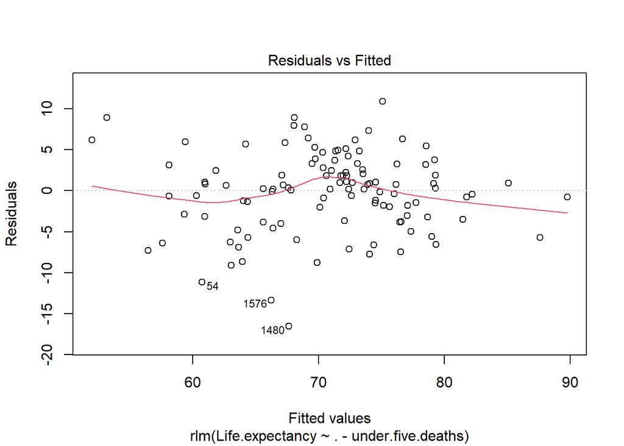

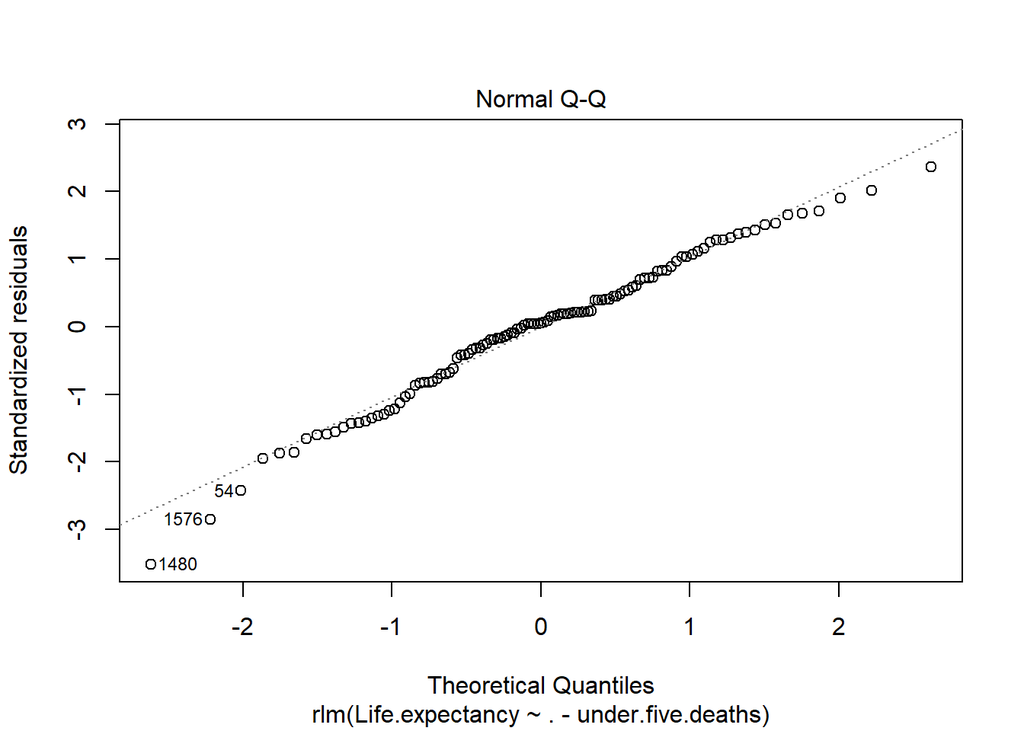

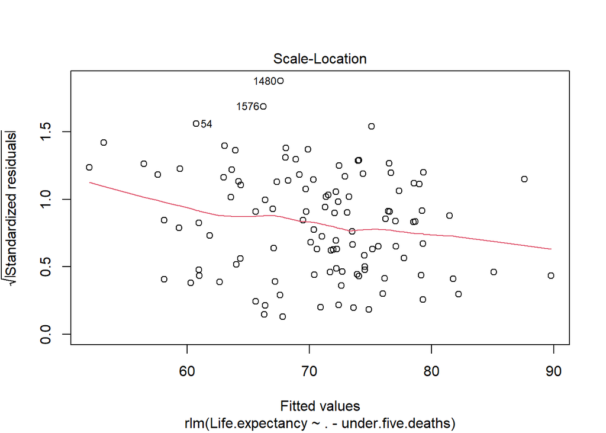

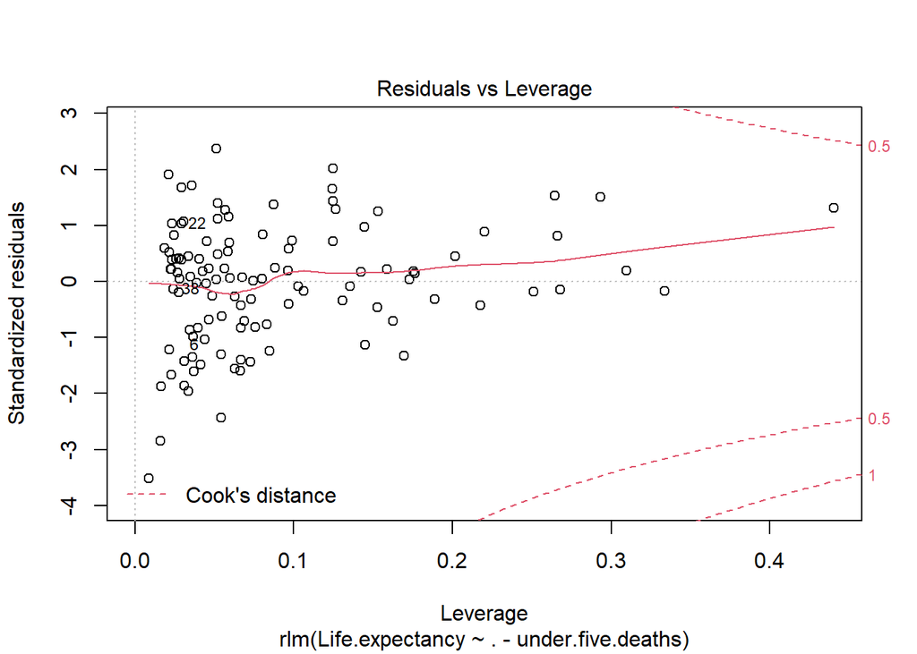

```r
## Huber’s method
ghuber <- rlm(Life.expectancy ~ .-under.five.deaths, data=train_data)
plot(ghuber)
```

```r
summary(ghuber)
```

```
##
## Call: rlm(formula = Life.expectancy ~ . - under.five.deaths, data = train_data)
## Residuals:
##      Min       1Q   Median       3Q      Max
## -16.5503  -3.1889   0.2724   3.1586  10.9002
##
## Coefficients:
##                  Value   Std. Error t value
## (Intercept)      44.9313  3.6539    12.2968
## StatusDeveloping -2.3342  1.8997    -1.2287
## infant.deaths     0.0020  0.0158     0.1295
## Alcohol          -0.2926  0.1794    -1.6307
## Hepatitis.B      -0.0129  0.0287    -0.4514
## BMI               0.0517  0.0290     1.7829
## Polio            -0.0041  0.0331    -0.1226
## Diphtheria        0.0588  0.0445     1.3198
## GDP               0.0000  0.0001     0.7345
## Schooling         1.8685  0.2877     6.4934
##
## Residual standard error: 4.722 on 103 degrees of freedom
```

```r
2*(1-pt(abs(coef(summary(ghuber)))[,"t value"],df=n_tr-p_tr-1-1))
```

```
##      (Intercept) StatusDeveloping    infant.deaths          Alcohol
##     0.000000e+00     2.219842e-01     8.971892e-01     1.060116e-01
##      Hepatitis.B              BMI            Polio       Diphtheria
##     6.526817e-01     7.755503e-02     9.026370e-01     1.898226e-01
##              GDP        Schooling
##     4.643014e-01     3.010580e-09
```

```r
# GAM
require(mgcv)
```

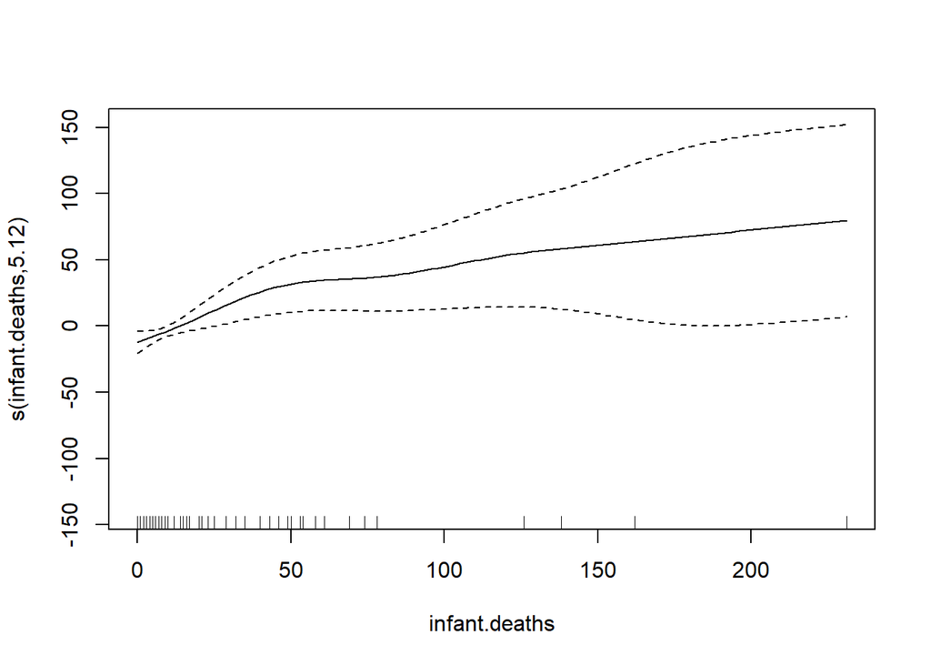

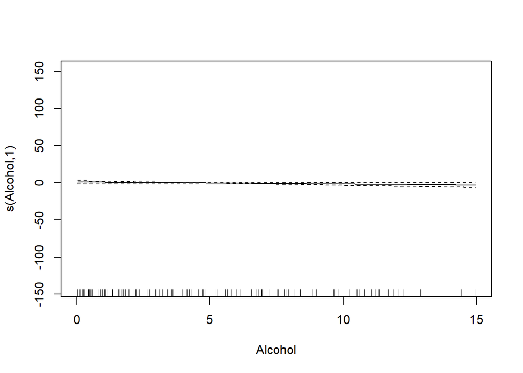

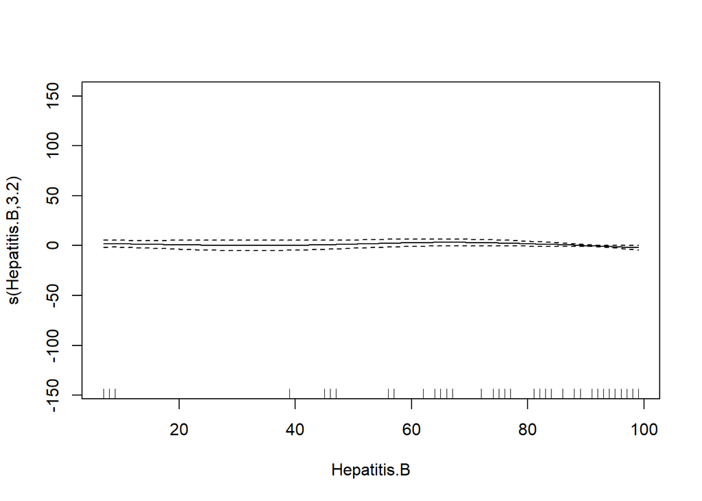

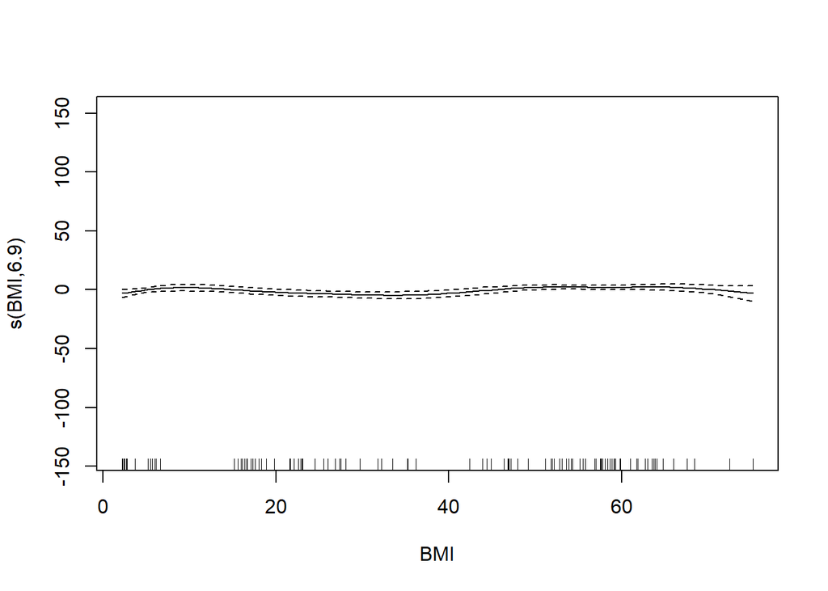

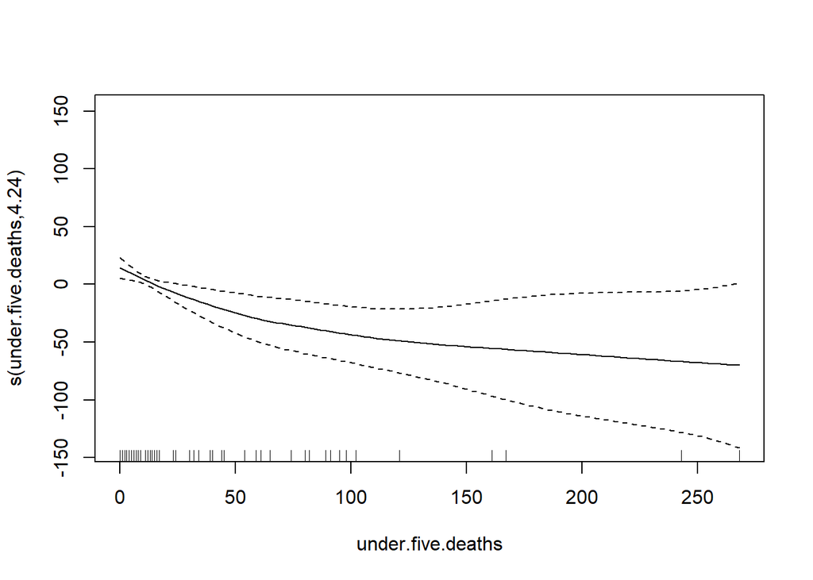

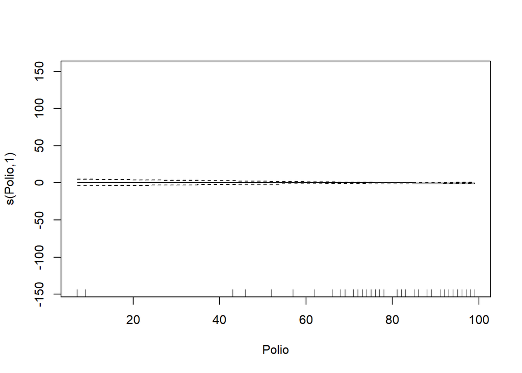

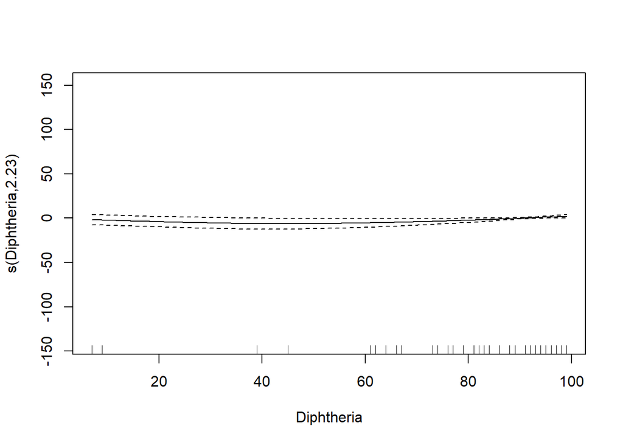

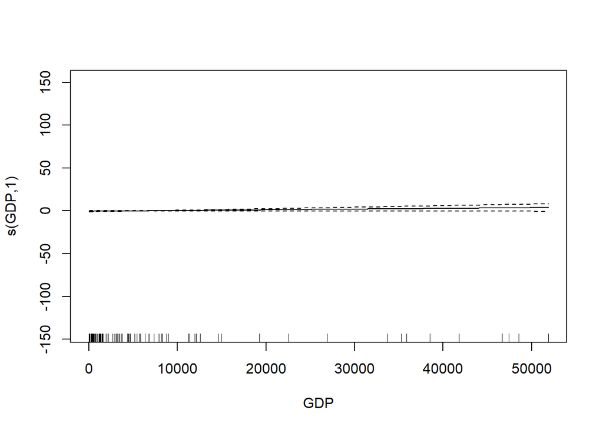

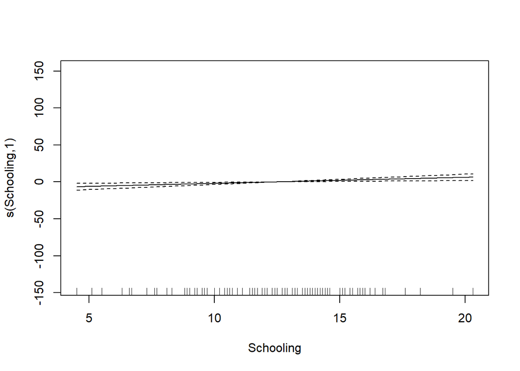

```r
gamod=gam(Life.expectancy ~factor(Status)+s(infant.deaths)+s(Alcohol)+s(Hepatitis.B)+s(BMI)+s(under.five.deaths)+s(Polio)+s(Diphtheria)+s(GDP)+s(Schooling),data=train_data)
plot(gamod)
```

```r
gamod
```

```
##
## Family: gaussian
## Link function: identity
##
## Formula:
## Life.expectancy ~ factor(Status) + s(infant.deaths) + s(Alcohol) +
##     s(Hepatitis.B) + s(BMI) + s(under.five.deaths) + s(Polio) +
##     s(Diphtheria) + s(GDP) + s(Schooling)
##
## Estimated degrees of freedom:
## 5.12 1.00 3.20 6.90 4.24 1.00 2.23
## 1.00 1.00  total = 27.69
##
## GCV score: 22.0252
```

```r
summary(gamod)
```

```
##
## Family: gaussian
## Link function: identity
##
## Formula:
## Life.expectancy ~ factor(Status) + s(infant.deaths) + s(Alcohol) +
##     s(Hepatitis.B) + s(BMI) + s(under.five.deaths) + s(Polio) +
##     s(Diphtheria) + s(GDP) + s(Schooling)
##
## Parametric coefficients:
##                          Estimate Std. Error t value Pr(>|t|)
## (Intercept)                72.910      1.412  51.642   <2e-16 ***
## factor(Status)Developing   -2.800      1.599  -1.751   0.0836 .
## ---
## Signif. codes:  0 '***' 0.001 '**' 0.01 '*' 0.05 '.' 0.1 ' ' 1
##
## Approximate significance of smooth terms:
##                        edf Ref.df     F p-value
## s(infant.deaths)     5.121  5.900 2.171 0.05419 .
## s(Alcohol)           1.000  1.000 3.003 0.08672 .
## s(Hepatitis.B)       3.204  3.822 1.488 0.25318
## s(BMI)               6.897  7.954 2.594 0.01310 *
## s(under.five.deaths) 4.236  4.947 2.756 0.02617 *
## s(Polio)             1.000  1.000 0.040 0.84245
## s(Diphtheria)        2.231  2.693 1.849 0.13087
## s(GDP)               1.000  1.000 3.059 0.08391 .
## s(Schooling)         1.000  1.000 8.129 0.00547 **
## ---
## Signif. codes:  0 '***' 0.001 '**' 0.01 '*' 0.05 '.' 0.1 ' ' 1
##
## R-sq.(adj) =  0.776   Deviance explained = 82.9%
## GCV = 22.025  Scale est. = 16.628    n = 113
```

```r
rmse <- function(x, y) { sqrt(mean( (x - y)^2 ))}
# LASSO
library(lars)
set.seed(123)
trainy <- train_data$Life.expectancy
trainx <- as.matrix(train_data[,c(-1,-2)])
modlasso <- lars(trainx,trainy)
#CV
modlasso.cv <- cv.lars(trainx,trainy,K=10,index=seq(from = 0.01,
to = 1, length =100))
```

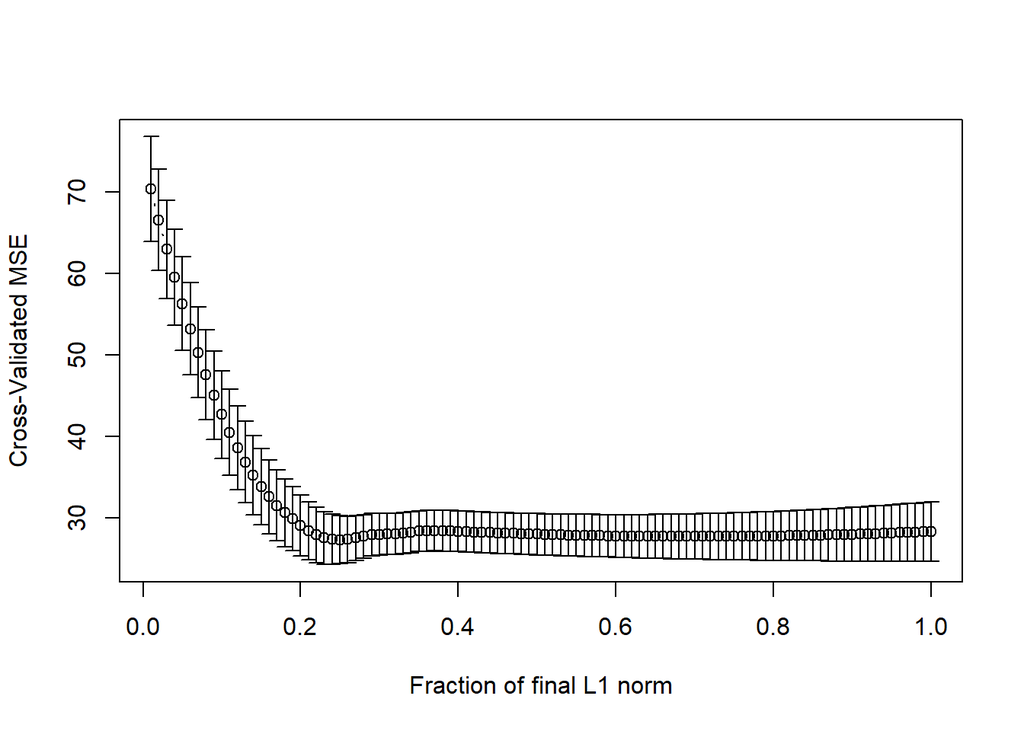

```r
parameter.hat<-modlasso.cv$index[which.min(modlasso.cv$cv)]
parameter.hat
```

```
## [1] 0.25
```

```r
testx <- as.matrix(test_data[,c(-1,-2)])
predlars <- predict(modlasso,testx,s=parameter.hat,mode="fraction")
rmse(test_data$Life.expectancy, predlars$fit)
```

```
## [1] 6.704263
```

```r
library(glmnet)
```

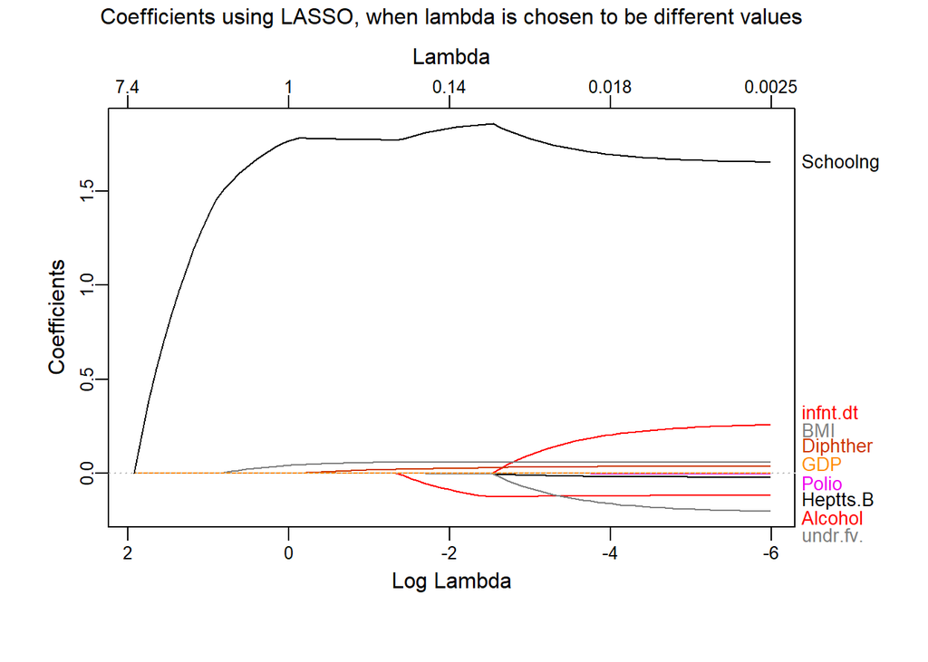

```r
mod=glmnet(as.matrix(train_data[,c(-1,-2)]),train_data$Life.expectancy)
library(plotmo)
plot_glmnet(mod,main="Coefficients using LASSO, when lambda is chosen to be different values")
```

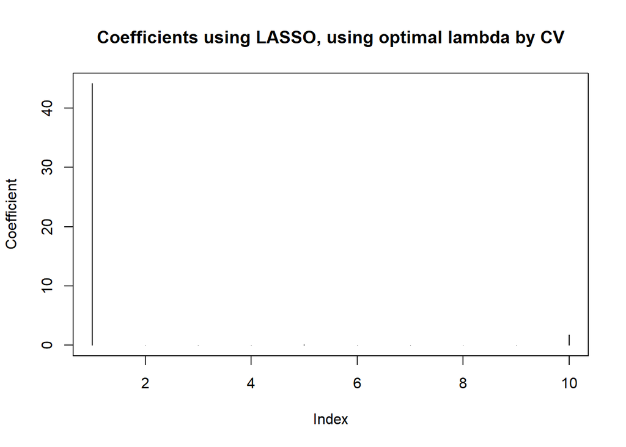

```r
model_lasso=glmnet(as.matrix(train_data[,c(-1,-2)]),train_data$Life.expectancy,alpha=1,lambda=0.25)
plot(coef(model_lasso),type="h",ylab="Coefficient",main="Coefficients using LASSO, using optimal lambda by CV")
```

```r
coef(model_lasso)
```

```
## 10 x 1 sparse Matrix of class "dgCMatrix"
##                              s0
## (Intercept)        4.412259e+01
## infant.deaths      .
## Alcohol           -5.955099e-03
## Hepatitis.B        .
## BMI                5.890137e-02
## under.five.deaths -9.533970e-04
## Polio              .
## Diphtheria         2.089965e-02
## GDP                4.727448e-05
## Schooling          1.773909e+00
```

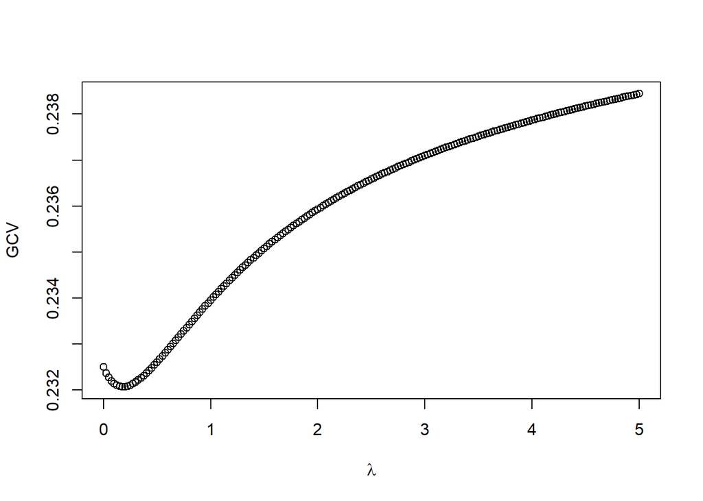

```r
#Ridge regression
lambda.set=seq(0, 5, len=201)
modrg <- lm.ridge(Life.expectancy ~ ., train_data, lambda = lambda.set)
plot(x=lambda.set,y=modrg$GCV,xlab=expression(lambda),ylab="GCV")
```

```r
which.min(modrg$GCV)
```

```
## 0.175
##     8
```

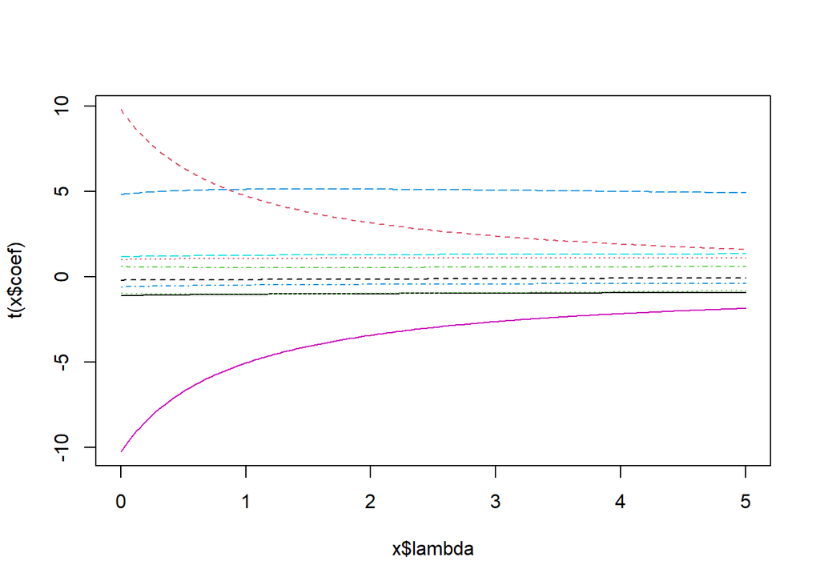

```r
plot(modrg)
```

```r
select(modrg)
```

```
## modified HKB estimator is 0.8412627
## modified L-W estimator is 3.746803
## smallest value of GCV  at 0.175
```

```r
model_ridge=lm.ridge(Life.expectancy ~ ., train_data,lambda = 0.075)
summary(model_ridge)
```

```
##        Length Class  Mode
## coef   10     -none- numeric
## scales 10     -none- numeric
## Inter   1     -none- numeric
## lambda  1     -none- numeric
## ym      1     -none- numeric
## xm     10     -none- numeric
## GCV     1     -none- numeric
## kHKB    1     -none- numeric
## kLW     1     -none- numeric
```

```r
coef(model_ridge)
```

```
##                    StatusDeveloping     infant.deaths           Alcohol
##      5.058832e+01     -3.063736e+00      2.628629e-01     -2.430814e-01
##       Hepatitis.B               BMI under.five.deaths             Polio
##     -2.368477e-02      5.557651e-02     -2.069279e-01     -8.333645e-03
##        Diphtheria               GDP         Schooling
##      4.778970e-02      5.154331e-05      1.618991e+00
```

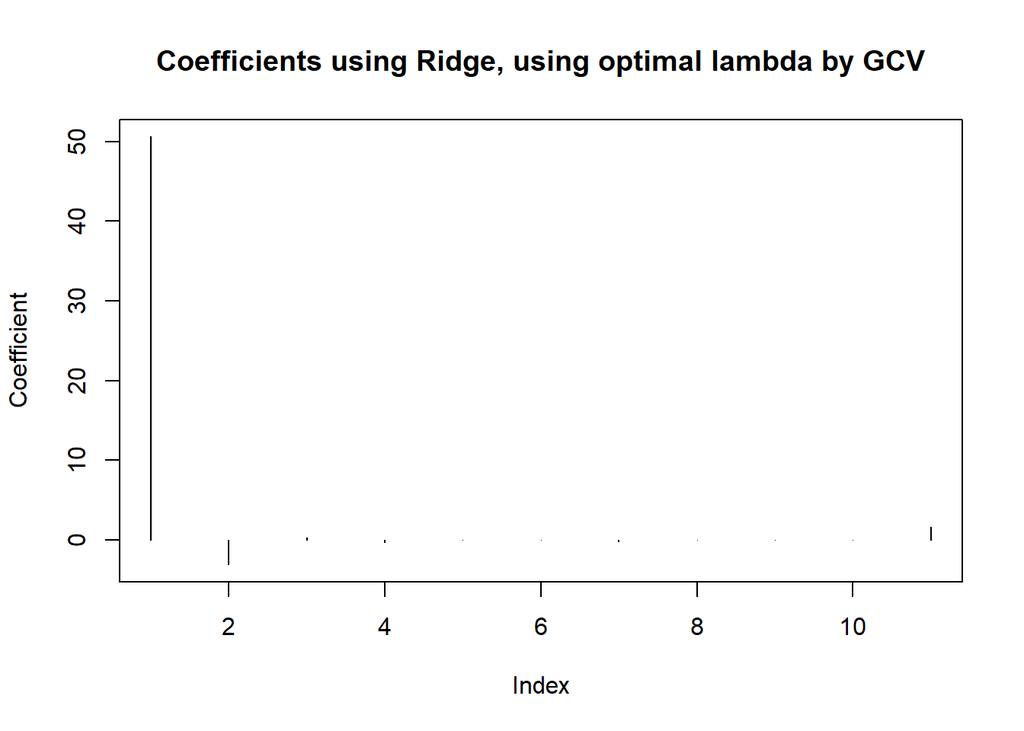

```r
plot(coef(model_ridge),type="h",ylab="Coefficient",main="Coefficients using Ridge, using optimal lambda by GCV")
```

```r
rmse <- function(x, y) { sqrt(mean( (x - y)^2 ))}
# boxcox transformation, lambda=3, Life.expectancy^(3) ~ Status+Alcohol+BMI+GDP+Schooling
rmse((model_1$fitted.values)^(1/3),train_data$Life.expectancy)
```

```
## [1] 4.889376
```

```r
rmse((predict(model_1,newdata=test_data))^(1/3),test_data$Life.expectancy)
```

```
## [1] 6.48582
```

```r
# linear model, no transformation, keep under.five.deaths
rmse((model_linear$fitted.values),train_data$Life.expectancy)
```

```
## [1] 4.672036
```

```r
rmse((predict(model_linear,newdata=test_data)),test_data$Life.expectancy)
```

```
## [1] 6.138647
```

```r
# linear model, no transformation, Life.expectancy ~.-under.five.deaths
rmse((g$fitted.values),train_data$Life.expectancy)
```

```
## [1] 4.843292
```

```r
rmse((predict(g,newdata=test_data)),test_data$Life.expectancy)
```

```
## [1] 6.397286
```

```r
# Life.expectancy^(3) ~ BMI+GDP+Schooling
rmse((model_2$fitted.values)^(1/3),train_data$Life.expectancy)
```

```
## [1] 4.988197
```

```r
rmse((predict(model_2,newdata=test_data))^(1/3),test_data$Life.expectancy)
```

```
## [1] 6.770469
```

```r
# Life.expectancy^(3) ~ .-infant.deaths-Polio-under.five.deaths
rmse((model_3$fitted.values)^(1/3),train_data$Life.expectancy)
```

```
## [1] 4.891125
```

```r
rmse((predict(model_3,newdata=test_data))^(1/3),test_data$Life.expectancy)
```

```
## [1] 6.729464
```

```r
# Huber Life.expectancy ~ .-under.five.deaths
rmse((ghuber$fitted.values),train_data$Life.expectancy)
```

```
## [1] 4.85814
```

```r
rmse((predict(ghuber,newdata=test_data)),test_data$Life.expectancy)
```

```
## [1] 6.529678
```

```r
# GAM Life.expectancy ~factor(Status)+s(infant.deaths)+s(Alcohol)+s(Hepatitis.B)+s(BMI)+s(under.five.deaths)+s(Polio)+s(Diphtheria)+s(GDP)+s(Schooling)
rmse((gamod$fitted.values),train_data$Life.expectancy)
```

```
## [1] 3.543105
```

```r
rmse((predict(gamod,newdata=test_data)),test_data$Life.expectancy)
```

```
## [1] 4.979254
```

```r
# Least absolute deviations
rmse((glad$fitted.values),train_data$Life.expectancy)
```

```
## [1] 4.928453
```

```r
rmse((predict(glad,newdata=test_data)),test_data$Life.expectancy)
```

```
## [1] 6.795534
```

```r
anova(model_1,model_2)
```

```
## Analysis of Variance Table
##
## Model 1: Life.expectancy^(3) ~ Status + Alcohol + BMI + GDP + Schooling
## Model 2: Life.expectancy^(3) ~ BMI + GDP + Schooling
##   Res.Df        RSS Df   Sum of Sq      F Pr(>F)
## 1    107 5.2209e+11
## 2    109 5.4201e+11 -2 -1.9919e+10 2.0412 0.1349
```

```r
summary(model_1)
```

```
##
## Call:
## lm(formula = Life.expectancy^(3) ~ Status + Alcohol + BMI + GDP +
##     Schooling, data = train_data)
##
## Residuals:
##     Min      1Q  Median      3Q     Max
## -176900  -53870    2720   48259  192541
##
## Coefficients:
##                    Estimate Std. Error t value Pr(>|t|)
## (Intercept)       4.478e+04  4.402e+04   1.017   0.3113
## StatusDeveloping -4.752e+04  2.501e+04  -1.900   0.0601 .
## Alcohol          -3.405e+03  2.372e+03  -1.436   0.1540
## BMI               7.565e+02  3.733e+02   2.026   0.0452 *
## GDP               1.169e+00  7.386e-01   1.583   0.1163
## Schooling         2.738e+04  3.442e+03   7.955    2e-12 ***
## ---
## Signif. codes:  0 '***' 0.001 '**' 0.01 '*' 0.05 '.' 0.1 ' ' 1
##
## Residual standard error: 69850 on 107 degrees of freedom
## Multiple R-squared:  0.6934, Adjusted R-squared:  0.6791
## F-statistic: 48.41 on 5 and 107 DF,  p-value: < 2.2e-16
```

```r
confint(model_1)
```

```
##                          2.5 %       97.5 %
## (Intercept)      -4.248236e+04 1.320383e+05
## StatusDeveloping -9.709933e+04 2.057511e+03
## Alcohol          -8.106767e+03 1.296918e+03
## BMI               1.639111e+01 1.496550e+03
## GDP              -2.947662e-01 2.633576e+00
## Schooling         2.055808e+04 3.420588e+04
```

First I eliminate all rows with NAs, and rows with data entry errors(infant.deaths and under.five.deaths greater than 1000). I find that there is collinearity in the predcitors, because some of the predictors have similar meaning, such as infant or child death rate, or vaccination rate. Second, I eliminate some influential points and leverage points. After doing the linear models with all predictors, I found the parameter of infant.deaths is positive, which is not reasonable. It could be the unstable results of collinearity. So we remove under.five.deaths and do the linear model again. After doing diagnostics, I find there is some heteroscadesticity in residuals and residuals seem to be long-tailed distributed. I tried Box-Cox transformation to the response to the power of 3. I find that after response transformation, the heteroscadesiticity disappear and the residuals follow short-tailed distribution. After do variable selection, we choose five predictors:StatusDeveloping, Alcohol, BMI, GDP, Schooling, because they have the smallest AIC and Marllow’s Cp. I tried different robust methods and find their rmse are not significantly different from least square method.